# CMSC 320 Final Project: Analyzing the Global Terrorism Database

### By Omeed Zarrabian and Adithya Raj

## Introduction

Terrorism is an issue that many countries and governments face when trying to maintain peace within their country. Terrorist groups can form for many reasons, traditionally stemming from the extreme radicalization of certain beliefs. This process of radicalization eventually leads to a plethora of terrorist attacks. While the general goal of an attack is to gain attention for the group and to inflict harm on a population, these attacks can be of various magnitudes, can be of different types, and can have various other factors that set them apart from each other. The Global Terrorism Database helps to classify over 180,000 attacks that occurred from 1970 to 2017.

For our final project, we decided to use the Global Terrorism Database in order to figure out whether or not we could predict whether or not an attack was classified as a success. While there are many potential metrics that can determine whether or not it was successful, the database comes with a column that states whether or not the success was successful. This database kept track of and itemized every terrorist attack from the years 1970 - 2017. We were interested in whether or not we could predict whether or not an attack would be successful, and that is what we decided to base our project on.

## Reading and Cleaning the Data

```python
import matplotlib as plt
import seaborn as sns
import pandas as pd
import numpy as np
import plotly.express as px
```

```python
df = pd.read_csv(r'globalterrorismdb_0718dist.csv', encoding='ISO-8859-1')
df.head()
df
```

|  | eventid | iyear | imonth | iday | approxdate | extended | resolution | country | country_txt | region | ... | addnotes | scite1 | scite2 | scite3 | dbsource | INT_LOG | INT_IDEO | INT_MISC | INT_ANY | related |
| --- | --- | --- | --- | --- | --- | --- | --- | --- | --- | --- | --- | --- | --- | --- | --- | --- | --- | --- | --- | --- | --- |
| 0 | 197000000001 | 1970 | 7 | 2 | NaN | 0 | NaN | 58 | Dominican Republic | 2 | ... | NaN | NaN | NaN | NaN | PGIS | 0 | 0 | 0 | 0 | NaN |
| 1 | 197000000002 | 1970 | 0 | 0 | NaN | 0 | NaN | 130 | Mexico | 1 | ... | NaN | NaN | NaN | NaN | PGIS | 0 | 1 | 1 | 1 | NaN |
| 2 | 197001000001 | 1970 | 1 | 0 | NaN | 0 | NaN | 160 | Philippines | 5 | ... | NaN | NaN | NaN | NaN | PGIS | -9 | -9 | 1 | 1 | NaN |
| 3 | 197001000002 | 1970 | 1 | 0 | NaN | 0 | NaN | 78 | Greece | 8 | ... | NaN | NaN | NaN | NaN | PGIS | -9 | -9 | 1 | 1 | NaN |
| 4 | 197001000003 | 1970 | 1 | 0 | NaN | 0 | NaN | 101 | Japan | 4 | ... | NaN | NaN | NaN | NaN | PGIS | -9 | -9 | 1 | 1 | NaN |
| ... | ... | ... | ... | ... | ... | ... | ... | ... | ... | ... | ... | ... | ... | ... | ... | ... | ... | ... | ... | ... | ... |
| 181686 | 201712310022 | 2017 | 12 | 31 | NaN | 0 | NaN | 182 | Somalia | 11 | ... | NaN | "Somalia: Al-Shabaab Militants Attack Army Che... | "Highlights: Somalia Daily Media Highlights 2 ... | "Highlights: Somalia Daily Media Highlights 1 ... | START Primary Collection | 0 | 0 | 0 | 0 | NaN |
| 181687 | 201712310029 | 2017 | 12 | 31 | NaN | 0 | NaN | 200 | Syria | 10 | ... | NaN | "Putin's 'victory' in Syria has turned into a ... | "Two Russian soldiers killed at Hmeymim base i... | "Two Russian servicemen killed in Syria mortar... | START Primary Collection | -9 | -9 | 1 | 1 | NaN |
| 181688 | 201712310030 | 2017 | 12 | 31 | NaN | 0 | NaN | 160 | Philippines | 5 | ... | NaN | "Maguindanao clashes trap tribe members," Phil... | NaN | NaN | START Primary Collection | 0 | 0 | 0 | 0 | NaN |
| 181689 | 201712310031 | 2017 | 12 | 31 | NaN | 0 | NaN | 92 | India | 6 | ... | NaN | "Trader escapes grenade attack in Imphal," Bus... | NaN | NaN | START Primary Collection | -9 | -9 | 0 | -9 | NaN |
| 181690 | 201712310032 | 2017 | 12 | 31 | NaN | 0 | NaN | 160 | Philippines | 5 | ... | NaN | "Security tightened in Cotabato following IED ... | "Security tightened in Cotabato City," Manila ... | NaN | START Primary Collection | -9 | -9 | 0 | -9 | NaN |

181691 rows × 135 columns

At this point, we can see that database is big, and also has a lot of information that we don't necessarily need. There were a bunch of columns that weren't useful. For example, the location column usually had like a street on it, even though there is lso a longitude and latitude given for the attack, similarly, we're not interested in the scite1, scite2, scite3, resolution, multiple, and approxdate columns. while the approxdate column might seem useful, they also give the year, month, and date as columns, so the approxdate column is mundane. So pruning the dataset is necessary.

```python
df.drop(['approxdate', 'location', 'resolution', 'multiple', 'motive',
        'scite1', 'scite2', 'scite3'], axis=1, inplace=True)
df = df.rename(columns={"country": "country_id", "alternative": "alternative_id", "region": "region_id", "gname": "group_name"})
rows = df.shape[0]
```

```python
df = df[df['latitude'].notna()]
df = df[df['longitude'].notna()]
dropped_rows = df.shape[0]

noloc_rows = rows - dropped_rows
print("The number of rows with no latitude/longitude information is {}".format(noloc_rows))
```

[output not shown]

While we are interested in the location of an attack, a longitude and latidude are necessary in order to determine said location. Since the dataset has a little over 180,000 rows, dropping 4,500 rows makes the data loss minimal at best and makes the dataset easier to work with.

```python
df['group_name'].isna().sum() #no null values for terrorism group name
df['country_txt'].isna().sum() #no null values for country

df['iyear'].isna().sum()
df['imonth'].isna().sum()
df['iday'].isna().sum()

#no null values for date columns, so I can merge columns accurately
```

```
0
```

Having a missing year, month, or day would make the dataset also hard to work with, but luckily, all of these were populated, which makes the next step simpler. There were also no null values for the country or the name of a group committing an attack, so that also makes it a little easier to deal with the data frame.

```python
dtypes = df.dtypes
dtypes
df['iday'] = df['iday'].replace(0,1)
df['imonth'] = df['imonth'].replace(0,1)
df["Date"] = df["iyear"].apply(str) + "/" + df["imonth"].apply(str) + "/" + df["iday"].apply(str)
df['Date'] =  pd.to_datetime(df['Date'])

#moving datetime column to the front:
date_col = df.pop("Date")
df.insert(0, date_col.name, date_col)
df
```

|  | Date | eventid | iyear | imonth | iday | extended | country_id | country_txt | region_id | region_txt | ... | hostkidoutcome | hostkidoutcome_txt | nreleased | addnotes | dbsource | INT_LOG | INT_IDEO | INT_MISC | INT_ANY | related |
| --- | --- | --- | --- | --- | --- | --- | --- | --- | --- | --- | --- | --- | --- | --- | --- | --- | --- | --- | --- | --- | --- |
| 0 | 1970-07-02 | 197000000001 | 1970 | 7 | 2 | 0 | 58 | Dominican Republic | 2 | Central America & Caribbean | ... | NaN | NaN | NaN | NaN | PGIS | 0 | 0 | 0 | 0 | NaN |
| 1 | 1970-01-01 | 197000000002 | 1970 | 1 | 1 | 0 | 130 | Mexico | 1 | North America | ... | NaN | NaN | NaN | NaN | PGIS | 0 | 1 | 1 | 1 | NaN |
| 2 | 1970-01-01 | 197001000001 | 1970 | 1 | 1 | 0 | 160 | Philippines | 5 | Southeast Asia | ... | NaN | NaN | NaN | NaN | PGIS | -9 | -9 | 1 | 1 | NaN |
| 3 | 1970-01-01 | 197001000002 | 1970 | 1 | 1 | 0 | 78 | Greece | 8 | Western Europe | ... | NaN | NaN | NaN | NaN | PGIS | -9 | -9 | 1 | 1 | NaN |
| 4 | 1970-01-01 | 197001000003 | 1970 | 1 | 1 | 0 | 101 | Japan | 4 | East Asia | ... | NaN | NaN | NaN | NaN | PGIS | -9 | -9 | 1 | 1 | NaN |
| ... | ... | ... | ... | ... | ... | ... | ... | ... | ... | ... | ... | ... | ... | ... | ... | ... | ... | ... | ... | ... | ... |
| 181686 | 2017-12-31 | 201712310022 | 2017 | 12 | 31 | 0 | 182 | Somalia | 11 | Sub-Saharan Africa | ... | NaN | NaN | NaN | NaN | START Primary Collection | 0 | 0 | 0 | 0 | NaN |
| 181687 | 2017-12-31 | 201712310029 | 2017 | 12 | 31 | 0 | 200 | Syria | 10 | Middle East & North Africa | ... | NaN | NaN | NaN | NaN | START Primary Collection | -9 | -9 | 1 | 1 | NaN |
| 181688 | 2017-12-31 | 201712310030 | 2017 | 12 | 31 | 0 | 160 | Philippines | 5 | Southeast Asia | ... | NaN | NaN | NaN | NaN | START Primary Collection | 0 | 0 | 0 | 0 | NaN |
| 181689 | 2017-12-31 | 201712310031 | 2017 | 12 | 31 | 0 | 92 | India | 6 | South Asia | ... | NaN | NaN | NaN | NaN | START Primary Collection | -9 | -9 | 0 | -9 | NaN |
| 181690 | 2017-12-31 | 201712310032 | 2017 | 12 | 31 | 0 | 160 | Philippines | 5 | Southeast Asia | ... | NaN | NaN | NaN | NaN | START Primary Collection | -9 | -9 | 0 | -9 | NaN |

177134 rows × 128 columns

The above code combines the day, month, and year columns in order to make one simplified date. It was also necessary to replace some of the values in the day and month column with 1, as many of them had 0, but there isn't a 0th day of the month.

# Data Exploration and Visualization

```python
from wordcloud import WordCloud, STOPWORDS, ImageColorGenerator

#df["summary"]=df["summary"].astype(str)
#summary_str = " ".join(summ for summ in df["summary"])
#stopwords = set(STOPWORDS)
#stopwords.update(["the", "and", "so", "are", "because", "at", "in", "no", "however"])
#wordcloud = WordCloud(stopwords=stopwords, background_color="white").generate(text)

#plt.imshow(wordcloud, interpolation='bilinear')
#plt.axis("off")
#plt.show()

#figure out how to do wordcloud, currently not working
```

```
Top 30 countries with the most terrorist attacks since 1970
```

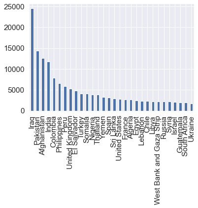

```python
print("Top 30 countries with the most terrorist attacks since 1970")
df['country_txt'].value_counts(sort=True)[:30].plot.bar()
```

```
Top 30 countries with the most terrorist between 2016-2017 (last 2 years in dataset)
```

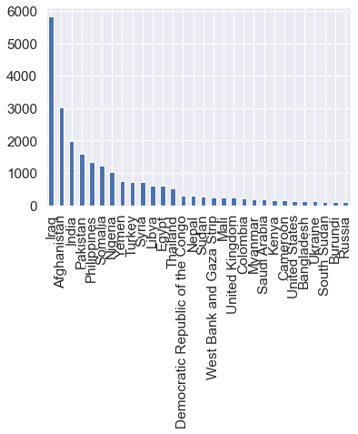

```python
recent_df = df.loc[df['iyear'] > 2015]
print("Top 30 countries with the most terrorist between 2016-2017 (last 2 years in dataset)")
recent_df['country_txt'].value_counts(sort=True)[:30].plot.bar()
```

[output not shown]

[output cut: 26 more lines]

[output not shown]